# time_series

### Time Series Methods

Before we start forecasting, we need to know how to **organize** the data for time series methods!. This notebook introduces how to format time series objects correctly and introduces the idea of the **sampling frequency** associated with measurements. Common visualizations are demonstrated including lag plots and autocorrelation plots. Time series decomposition with the classic additive decomposition method are demonstrated on a simple data set. The decomposition results are visualized, as is the **seasonally adjusted trend**.

## Import Modules

```python
import numpy as np
import pandas as pd
import matplotlib.pyplot as plt

import seaborn as sns
```

Most of the time series methods are part of `statsmodels`.

```python
import statsmodels.api as sm
```

## Read data

We will work with the El Nino temperature data set. The data are available from `statsmodels`. A link with a description of the data is provided below.

https://www.statsmodels.org/stable/datasets/generated/elnino.html

The data are imported via a `statsmodels` function in the cell below.

```python
dta = sm.datasets.elnino.load_pandas().data
```

The data consists of 13 columns. There is 1 column for each month in the year and a column which stores the year. Thus, one row corresponds to all monthly measurements within a single year!

```python
dta.info()
```

```
<class 'pandas.core.frame.DataFrame'>
RangeIndex: 61 entries, 0 to 60
Data columns (total 13 columns):
 #   Column  Non-Null Count  Dtype
---  ------  --------------  -----
 0   YEAR    61 non-null     float64
 1   JAN     61 non-null     float64
 2   FEB     61 non-null     float64
 3   MAR     61 non-null     float64
 4   APR     61 non-null     float64
 5   MAY     61 non-null     float64
 6   JUN     61 non-null     float64
 7   JUL     61 non-null     float64
 8   AUG     61 non-null     float64
 9   SEP     61 non-null     float64
 10  OCT     61 non-null     float64
 11  NOV     61 non-null     float64
 12  DEC     61 non-null     float64
dtypes: float64(13)
memory usage: 6.3 KB
```

## Reorganize data

The first few rows of the data set are shown below with the `.head()` method.

```python
dta.head()
```

|  | YEAR | JAN | FEB | MAR | APR | MAY | JUN | JUL | AUG | SEP | OCT | NOV | DEC |
| --- | --- | --- | --- | --- | --- | --- | --- | --- | --- | --- | --- | --- | --- |
| 0 | 1950.0 | 23.11 | 24.20 | 25.37 | 23.86 | 23.03 | 21.57 | 20.63 | 20.15 | 19.67 | 20.03 | 20.02 | 21.80 |
| 1 | 1951.0 | 24.19 | 25.28 | 25.60 | 25.37 | 24.79 | 24.69 | 23.86 | 22.32 | 21.44 | 21.77 | 22.33 | 22.89 |
| 2 | 1952.0 | 24.52 | 26.21 | 26.37 | 24.73 | 23.71 | 22.34 | 20.89 | 20.02 | 19.63 | 20.40 | 20.77 | 22.39 |
| 3 | 1953.0 | 24.15 | 26.34 | 27.36 | 27.03 | 25.47 | 23.49 | 22.20 | 21.45 | 21.25 | 20.95 | 21.60 | 22.44 |
| 4 | 1954.0 | 23.02 | 25.00 | 25.33 | 22.97 | 21.73 | 20.77 | 19.52 | 19.33 | 18.95 | 19.11 | 20.27 | 21.30 |

The last few rows are shown via the `.tail()` method below.

```python
dta.tail()
```

|  | YEAR | JAN | FEB | MAR | APR | MAY | JUN | JUL | AUG | SEP | OCT | NOV | DEC |
| --- | --- | --- | --- | --- | --- | --- | --- | --- | --- | --- | --- | --- | --- |
| 56 | 2006.0 | 24.76 | 26.52 | 26.22 | 24.29 | 23.84 | 22.82 | 22.20 | 21.89 | 21.93 | 22.46 | 22.61 | 24.15 |
| 57 | 2007.0 | 25.82 | 26.81 | 26.41 | 24.96 | 23.05 | 21.61 | 21.05 | 19.95 | 19.85 | 19.31 | 19.82 | 21.15 |
| 58 | 2008.0 | 24.24 | 26.39 | 26.91 | 25.68 | 24.43 | 23.19 | 23.02 | 22.14 | 21.60 | 21.39 | 21.54 | 22.73 |
| 59 | 2009.0 | 24.39 | 25.53 | 25.48 | 25.84 | 24.95 | 24.09 | 23.09 | 22.03 | 21.48 | 21.64 | 21.99 | 23.21 |
| 60 | 2010.0 | 24.70 | 26.16 | 26.54 | 26.04 | 24.75 | 23.26 | 21.11 | 19.49 | 19.28 | 19.73 | 20.44 | 22.07 |

As previously mentioned, the data has one column for each month in a year. Although this looks like a well organized data set, we cannot use it for time series analysis in this state! We must reshape the data into **long-format**! The **wide-format** approach is common because it "looks" well organized. However, it is **not** TIDY! CMPINF 2110 dives into the concepts of TIDY data in more detail. However, for our purposes the key reason why the data are **not** TIDY is because the column names are **values**. The column names store the month the measurement was recorded. Instead, we need the data organized such that the month is a value contained within the rows of a column.

We will use the `.melt()` method to reshape the data. The argument `id_vars` is set to `YEAR`. The argument `value_vars` is set to all columns except `YEAR`. If you look closely as the previous output displays, `YEAR` is the zeroth column in the DataFrame. Thus, we can access all other column names easily as shown below.

```python
dta.columns[1:].to_list()
```

```
['JAN',
 'FEB',
 'MAR',
 'APR',
 'MAY',
 'JUN',
 'JUL',
 'AUG',
 'SEP',
 'OCT',
 'NOV',
 'DEC']
```

The data are reshaped to long-format below.

```python
lf = dta.melt( id_vars = ['YEAR'], value_vars = dta.columns[1:].to_list(), ignore_index=True )
```

The long-format data has 3 columns. The `YEAR` column and two new columns, `variable` and `value`.

```python
lf.info()
```

```
<class 'pandas.core.frame.DataFrame'>
RangeIndex: 732 entries, 0 to 731
Data columns (total 3 columns):
 #   Column    Non-Null Count  Dtype
---  ------    --------------  -----
 0   YEAR      732 non-null    float64
 1   variable  732 non-null    object
 2   value     732 non-null    float64
dtypes: float64(2), object(1)
memory usage: 17.3+ KB
```

The `variable` column stores the names of the months (the original wide-format column names). The `value` column stores the values associated with the months within a given year.

```python
lf.head()
```

|  | YEAR | variable | value |
| --- | --- | --- | --- |
| 0 | 1950.0 | JAN | 23.11 |
| 1 | 1951.0 | JAN | 24.19 |
| 2 | 1952.0 | JAN | 24.52 |
| 3 | 1953.0 | JAN | 24.15 |
| 4 | 1954.0 | JAN | 23.02 |

```python
lf.tail()
```

|  | YEAR | variable | value |
| --- | --- | --- | --- |
| 727 | 2006.0 | DEC | 24.15 |
| 728 | 2007.0 | DEC | 21.15 |
| 729 | 2008.0 | DEC | 22.73 |
| 730 | 2009.0 | DEC | 23.21 |
| 731 | 2010.0 | DEC | 22.07 |

We can confirm that the `variable` column consists of all 12 months using `.value_counts()`.

```python
lf.variable.value_counts()
```

```
variable
JAN    61
FEB    61
MAR    61
APR    61
MAY    61
JUN    61
JUL    61
AUG    61
SEP    61
OCT    61
NOV    61
DEC    61
Name: count, dtype: int64
```

One row now corresponds to a measurement in a month within a year! Thus, the measurements within 1950 are spread across 12 rows in the long-format data:

```python
lf.loc[ lf.YEAR == dta.YEAR.min(), : ]
```

|  | YEAR | variable | value |
| --- | --- | --- | --- |
| 0 | 1950.0 | JAN | 23.11 |
| 61 | 1950.0 | FEB | 24.20 |
| 122 | 1950.0 | MAR | 25.37 |
| 183 | 1950.0 | APR | 23.86 |
| 244 | 1950.0 | MAY | 23.03 |
| 305 | 1950.0 | JUN | 21.57 |
| 366 | 1950.0 | JUL | 20.63 |
| 427 | 1950.0 | AUG | 20.15 |
| 488 | 1950.0 | SEP | 19.67 |
| 549 | 1950.0 | OCT | 20.03 |
| 610 | 1950.0 | NOV | 20.02 |
| 671 | 1950.0 | DEC | 21.80 |

Contrast the above with the original wide-format data which spread the measurements across 12 columns in a single row.

```python
dta.loc[ dta.YEAR == dta.YEAR.min(), :]
```

|  | YEAR | JAN | FEB | MAR | APR | MAY | JUN | JUL | AUG | SEP | OCT | NOV | DEC |
| --- | --- | --- | --- | --- | --- | --- | --- | --- | --- | --- | --- | --- | --- |
| 0 | 1950.0 | 23.11 | 24.2 | 25.37 | 23.86 | 23.03 | 21.57 | 20.63 | 20.15 | 19.67 | 20.03 | 20.02 | 21.8 |

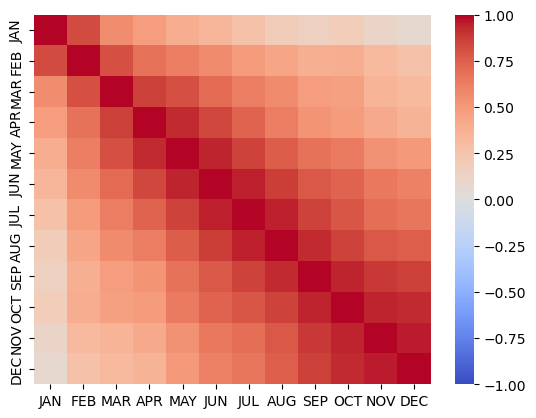

```python
fig, ax = plt.subplots()

sns.heatmap( dta.iloc[:, 1:].corr(),
            vmin=-1, vmax=1, center=0,
            cmap='coolwarm',
            ax=ax)

plt.show()
```

Long-format data is easier to group and aggregate and therefore summarize the data! For example, we can count the number of rows and number of unique years associated with each month. The cell below accomplishes this via the `.groupby().aggregate()` "chain". You should notice the results are the same as `.value_counts()`!

```python
lf.groupby(['variable']).\
aggregate(num_rows = ('value', 'size'),
          num_years = ('YEAR', 'nunique')).\
reset_index()
```

|  | variable | num_rows | num_years |
| --- | --- | --- | --- |
| 0 | APR | 61 | 61 |
| 1 | AUG | 61 | 61 |
| 2 | DEC | 61 | 61 |
| 3 | FEB | 61 | 61 |
| 4 | JAN | 61 | 61 |
| 5 | JUL | 61 | 61 |
| 6 | JUN | 61 | 61 |
| 7 | MAR | 61 | 61 |
| 8 | MAY | 61 | 61 |
| 9 | NOV | 61 | 61 |
| 10 | OCT | 61 | 61 |
| 11 | SEP | 61 | 61 |

The data cannot be provided to time series methods though. We must first create a **date time index**. At the moment we do not have that. We simply have the year, as a double floating point number (a decimal) and the abbreviated name of the month as text (a Pandas object data type). We will create a new column, `my_date`, which has the format YYYY-Month. There are several steps to creating the datetime column in this format. First, let's convert `YEAR` to an integer. The result is assigned to a NEW column `my_year` within the long-format data.

```python
lf['my_year'] = lf.YEAR.astype('int64')
```

```python
lf.info()
```

```
<class 'pandas.core.frame.DataFrame'>
RangeIndex: 732 entries, 0 to 731
Data columns (total 4 columns):
 #   Column    Non-Null Count  Dtype
---  ------    --------------  -----
 0   YEAR      732 non-null    float64
 1   variable  732 non-null    object
 2   value     732 non-null    float64
 3   my_year   732 non-null    int64
dtypes: float64(2), int64(1), object(1)
memory usage: 23.0+ KB
```

```python
lf.head()
```

|  | YEAR | variable | value | my_year |
| --- | --- | --- | --- | --- |
| 0 | 1950.0 | JAN | 23.11 | 1950 |
| 1 | 1951.0 | JAN | 24.19 | 1951 |
| 2 | 1952.0 | JAN | 24.52 | 1952 |
| 3 | 1953.0 | JAN | 24.15 | 1953 |
| 4 | 1954.0 | JAN | 23.02 | 1954 |

Next, let's convert `my_year` to a string (object) data type. Just why we are creating a string will be apparent shortly.

```python
lf['my_year'] = lf.my_year.astype('str')
```

```python
lf.info()
```

```
<class 'pandas.core.frame.DataFrame'>
RangeIndex: 732 entries, 0 to 731
Data columns (total 4 columns):
 #   Column    Non-Null Count  Dtype
---  ------    --------------  -----
 0   YEAR      732 non-null    float64
 1   variable  732 non-null    object
 2   value     732 non-null    float64
 3   my_year   732 non-null    object
dtypes: float64(2), object(2)
memory usage: 23.0+ KB
```

```python
lf.head()
```

|  | YEAR | variable | value | my_year |
| --- | --- | --- | --- | --- |
| 0 | 1950.0 | JAN | 23.11 | 1950 |
| 1 | 1951.0 | JAN | 24.19 | 1951 |
| 2 | 1952.0 | JAN | 24.52 | 1952 |
| 3 | 1953.0 | JAN | 24.15 | 1953 |
| 4 | 1954.0 | JAN | 23.02 | 1954 |

Next, concatenate the `my_year` string with the month abbreviation, within the `variable` column. Assign the result to a new column `my_date`. The `.str.cat()` method is used to concatenate or combine the two strings together. This method is only available for string data types and not integer data types. That's why the `my_year` column was forced to be a string! The `.str.cat()` method includes an argument `sep` which denotes how the combined strings are *separated*. I want the strings separated by a `-` character.

```python
lf['my_date'] = lf.my_year.str.cat( lf.variable, sep = '-' )
```

```python
lf.head()
```

|  | YEAR | variable | value | my_year | my_date |
| --- | --- | --- | --- | --- | --- |
| 0 | 1950.0 | JAN | 23.11 | 1950 | 1950-JAN |
| 1 | 1951.0 | JAN | 24.19 | 1951 | 1951-JAN |
| 2 | 1952.0 | JAN | 24.52 | 1952 | 1952-JAN |
| 3 | 1953.0 | JAN | 24.15 | 1953 | 1953-JAN |
| 4 | 1954.0 | JAN | 23.02 | 1954 | 1954-JAN |

The above display shows `my_date` has the YEAR and MONTH abbreviation separated by a `-` character. The `my_date` column now includes both the YEAR and MONTH the measurement is associated with! Although this looks like everything we need...the `my_date` column is a string! The `my_date` column does not "know" it's a date!

```python
lf.info()
```

```
<class 'pandas.core.frame.DataFrame'>
RangeIndex: 732 entries, 0 to 731
Data columns (total 5 columns):
 #   Column    Non-Null Count  Dtype
---  ------    --------------  -----
 0   YEAR      732 non-null    float64
 1   variable  732 non-null    object
 2   value     732 non-null    float64
 3   my_year   732 non-null    object
 4   my_date   732 non-null    object
dtypes: float64(2), object(3)
memory usage: 28.7+ KB
```

Let's now convert `my_date` into a date time object! The conversion is executed with the `pd.to_datetime()` function. This function will try to "guess" the appropriate date conversion based on some simple checks. The current format of YYYY-MON is an easy format for the function to figure out.

```python
pd.to_datetime( lf.my_date )
```

```
C:\Users\XPS15\AppData\Local\Temp\ipykernel_21032\2942030940.py:1: UserWarning: Could not infer format, so each element will be parsed individually, falling back to `dateutil`. To ensure parsing is consistent and as-expected, please specify a format.
  pd.to_datetime( lf.my_date )
```

```
0     1950-01-01
1     1951-01-01
2     1952-01-01
3     1953-01-01
4     1954-01-01
         ...
727   2006-12-01
728   2007-12-01
729   2008-12-01
730   2009-12-01
731   2010-12-01
Name: my_date, Length: 732, dtype: datetime64[ns]
```

A warning is displayed, but the conversion executed successfully. You can remove the warning by specifying the `format` argument. The specific value to set for `format` depends on how the date is "written". Special codes must be provided to parse the date. The `my_date` column is written as YYYY-MON and so we need to specify the special code for that format. There are many such special codes to denote years, months, days, and other aspects of a date time. For our specific purposes we need to use `'%Y-%b'` because of the YYYY-MON format. Please see the documentation for a complete list of the special codes for parsing date times.

https://docs.python.org/3/library/datetime.html#strftime-and-strptime-behavior

Providing the `format` for the special code removes the warning message, as shown below.

```python
pd.to_datetime( lf.my_date, format='%Y-%b')
```

```
0     1950-01-01
1     1951-01-01
2     1952-01-01
3     1953-01-01
4     1954-01-01
         ...
727   2006-12-01
728   2007-12-01
729   2008-12-01
730   2009-12-01
731   2010-12-01
Name: my_date, Length: 732, dtype: datetime64[ns]
```

Let's assign the result of the `pd.to_datetime()` function to a new column, `date_dt`, within `lf`. The cell below does not set the `format` argument and therefore requires `pd.to_datetime()` to guess the appropriate parsing action. I recommend to first try the default behavior and check if the conversion worked correctly. This way you do not need to look through the special codes unless you have to.

```python
lf['date_dt'] = pd.to_datetime( lf.my_date )
```

As shown below `date_dt` is a datetime object!

```python
lf.info()
```

```
<class 'pandas.core.frame.DataFrame'>
RangeIndex: 732 entries, 0 to 731
Data columns (total 6 columns):
 #   Column    Non-Null Count  Dtype
---  ------    --------------  -----
 0   YEAR      732 non-null    float64
 1   variable  732 non-null    object
 2   value     732 non-null    float64
 3   my_year   732 non-null    object
 4   my_date   732 non-null    object
 5   date_dt   732 non-null    datetime64[ns]
dtypes: datetime64[ns](1), float64(2), object(3)
memory usage: 34.4+ KB
```

Displaying the head and tail of the DataFrame reveals the `date_dt` column "looks" different from the previous `my_date` column!

```python
lf
```

|  | YEAR | variable | value | my_year | my_date | date_dt |
| --- | --- | --- | --- | --- | --- | --- |
| 0 | 1950.0 | JAN | 23.11 | 1950 | 1950-JAN | 1950-01-01 |
| 1 | 1951.0 | JAN | 24.19 | 1951 | 1951-JAN | 1951-01-01 |
| 2 | 1952.0 | JAN | 24.52 | 1952 | 1952-JAN | 1952-01-01 |
| 3 | 1953.0 | JAN | 24.15 | 1953 | 1953-JAN | 1953-01-01 |
| 4 | 1954.0 | JAN | 23.02 | 1954 | 1954-JAN | 1954-01-01 |
| ... | ... | ... | ... | ... | ... | ... |
| 727 | 2006.0 | DEC | 24.15 | 2006 | 2006-DEC | 2006-12-01 |
| 728 | 2007.0 | DEC | 21.15 | 2007 | 2007-DEC | 2007-12-01 |
| 729 | 2008.0 | DEC | 22.73 | 2008 | 2008-DEC | 2008-12-01 |
| 730 | 2009.0 | DEC | 23.21 | 2009 | 2009-DEC | 2009-12-01 |
| 731 | 2010.0 | DEC | 22.07 | 2010 | 2010-DEC | 2010-12-01 |

732 rows × 6 columns

The `date_dt` column is a new format, YYYY-MM-DD. Even though our data was not provided with a day, a date time object requires a year, a month, and a day. In this way, we have full access to the calendar information! Calender arithmetic is tricky. After all the day after February 28 is usually March 1, unless it's a leap year! We would have to manage calendar arithmetic if we kept the date as a string. However, we do not have to worry about such issues! The datetime object handles all the weird calendar problems for us!

The date time components can be separated using the `.dt.` attributes. For example, the YEAR component is extracted with `.dt.year`.

```python
lf.date_dt.dt.year
```

```
0      1950
1      1951
2      1952
3      1953
4      1954
       ...
727    2006
728    2007
729    2008
730    2009
731    2010
Name: date_dt, Length: 732, dtype: int32
```

While the MONTH component is extracted with `.dt.month`.

```python
lf.date_dt.dt.month
```

```
0       1
1       1
2       1
3       1
4       1
       ..
727    12
728    12
729    12
730    12
731    12
Name: date_dt, Length: 732, dtype: int32
```

These might not seem interesting since we already have the YEAR and MONTH in the data. However, we can extract other components like the QUARTER!

```python
lf.date_dt.dt.quarter
```

```
0      1
1      1
2      1
3      1
4      1
      ..
727    4
728    4
729    4
730    4
731    4
Name: date_dt, Length: 732, dtype: int32
```

Even though there are 12 MONTHS in a YEAR, there are only 4 QUARTERS in the YEAR.

```python
lf.date_dt.dt.quarter.value_counts()
```

```
date_dt
1    183
2    183
3    183
4    183
Name: count, dtype: int64
```

The date time components are very useful because you do **not** to figure out properties of the date. The date time components will give them to you!

We have created the necessary datetime object, but the data are still not ready for the time series methods. Most time series work with Pandas Series objects, not DataFrames. Therefore, we need to separate out the `value` column into it's own Series object.

```python
my_series = lf.value.copy()
```

```python
my_series
```

```
0      23.11
1      24.19
2      24.52
3      24.15
4      23.02
       ...
727    24.15
728    21.15
729    22.73
730    23.21
731    22.07
Name: value, Length: 732, dtype: float64
```

Time series methods require the index of a Series to be a datetime index. As shown below the index to `my_series` is just the default range index.

```python
print( my_series.index )
```

```
RangeIndex(start=0, stop=732, step=1)
```

```python
my_series.index = lf.date_dt
```

```python
print( my_series.index )
```

```
DatetimeIndex(['1950-01-01', '1951-01-01', '1952-01-01', '1953-01-01',
               '1954-01-01', '1955-01-01', '1956-01-01', '1957-01-01',
               '1958-01-01', '1959-01-01',
               ...
               '2001-12-01', '2002-12-01', '2003-12-01', '2004-12-01',
               '2005-12-01', '2006-12-01', '2007-12-01', '2008-12-01',
               '2009-12-01', '2010-12-01'],
              dtype='datetime64[ns]', name='date_dt', length=732, freq=None)
```

As we can see above, the index is now a datetimeindex! We are one step closer but, this index does **not** have a defined frequency. We can see that by the attribute `freq` being equal to `None` above. The frequency is **VERY IMPORTANT** in time series methods! It specifies the **sampling frequency** or rate that the data are collected. Let's go ahead and force that the frequency is the start of each month. In Pandas, we enforce or change the sampling frequency with the `.resample()` method. It is important to note that the `.resample()` method does **NOT** refer to resampling methods like cross-validation. It has to do with altering how time series data are stored.

The frequency is specified by an **offset alias**. Please see the link below for the many different options that are available.

https://pandas.pydata.org/pandas-docs/stable/user_guide/timeseries.html#offset-aliases

We are working with Monthly data and so our offset alias must be either the start, end, or middle of the month. We will use the start of the month frequency and so we will set the `rule` argument to `'MS'`. The resampled data **must** be **summarized** in order to aggregate repeat observations within the desired sampling frequency. The current example does not have any repeat observations within a single month, but the summary method is applied after the `.resample()` method. For example, the `.mean()` method is applied below to calculate the MEAN value associated with a month within a year if there are multiple measurements per month. The average of a single value is the value itself and so applying `.mean()` will not change the monthly values in the example.

```python
ready_series = my_series.copy().resample('MS').mean()
```

The index attribute is displayed for the original `my_series` object and the resampled `ready_series` object. Notice that the `freq` is now displayed as `'MS'` to represet that the `ready_series` index "knows" that each observation corresponds to the start of the month.

```python
print( my_series.index )
```

```
DatetimeIndex(['1950-01-01', '1951-01-01', '1952-01-01', '1953-01-01',
               '1954-01-01', '1955-01-01', '1956-01-01', '1957-01-01',
               '1958-01-01', '1959-01-01',
               ...
               '2001-12-01', '2002-12-01', '2003-12-01', '2004-12-01',
               '2005-12-01', '2006-12-01', '2007-12-01', '2008-12-01',
               '2009-12-01', '2010-12-01'],
              dtype='datetime64[ns]', name='date_dt', length=732, freq=None)
```

```python
print( ready_series.index )
```

```
DatetimeIndex(['1950-01-01', '1950-02-01', '1950-03-01', '1950-04-01',
               '1950-05-01', '1950-06-01', '1950-07-01', '1950-08-01',
               '1950-09-01', '1950-10-01',
               ...
               '2010-03-01', '2010-04-01', '2010-05-01', '2010-06-01',
               '2010-07-01', '2010-08-01', '2010-09-01', '2010-10-01',
               '2010-11-01', '2010-12-01'],
              dtype='datetime64[ns]', name='date_dt', length=732, freq='MS')
```

Printing the first few elements of the Series object will tell us the frequency of the DateTimeIndex as well.

```python
print( '-- original series --')
print( my_series.head() )
print( ' ' )
print( '-- after resampling --' )
print( ready_series.head() )
```

```
-- original series --
date_dt
1950-01-01    23.11
1951-01-01    24.19
1952-01-01    24.52
1953-01-01    24.15
1954-01-01    23.02
Name: value, dtype: float64

-- after resampling --
date_dt
1950-01-01    23.11
1950-02-01    24.20
1950-03-01    25.37
1950-04-01    23.86
1950-05-01    23.03
Freq: MS, Name: value, dtype: float64
```

Our time series object is now ready for modeling!

If you are still wondering why we need a defined sampling frequency, it is because most time methods require the data to be collected at **regular** or **fixed** intervals. Irregular time series frequencies are **very challenging**. We will not discuss such methods in this course. The `.resample()` method therefore ensures all measurements exist at some fixed regular interval.

## Visualizations

Let's start out by simply visualizing the time series. Series objects in Pandas have a default plot method which plots the value of the elements with respect to the index. Since we have a DateTimeIndex, the value in `ready_series` will be plotted with respect to the calendar date.

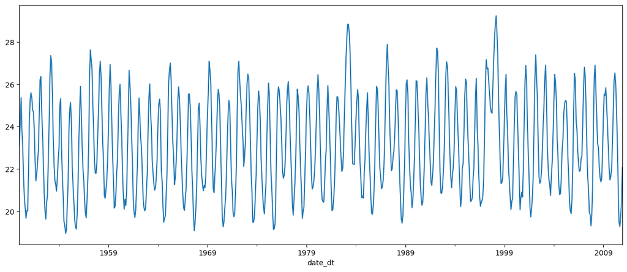

```python
ready_series.plot( figsize=(15, 6) )

plt.show()
```

We could have created the above figure with the DataFrame and un-resampled data using Seaborn. There's nothing wrong with the figure below, after all the data are the same as those shown in the previous figure. The previous figure though was created using the appropriately organized and resampled Pandas Series.

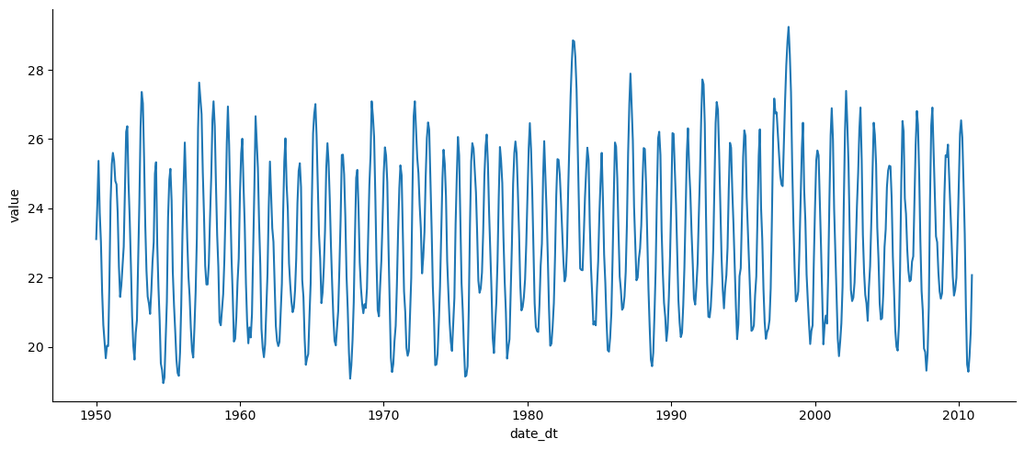

```python
sns.relplot(data = lf, x='date_dt', y='value', kind='line', aspect=2.25)

plt.show()
```

Let's look at the lag-plot to get an idea of the autocorrelation structure of the data. We can easily make the lag plot with the Pandas `pd.plotting.lag_plot()` method. The `lag` argument is how we specify the lag to consider. Below, we plot the value with respect to it's lagged value. The lag-plot reveals the linear relationship between two sequential measurements. The lag-plot is nothing more than a scatter plot, but it helps us understand relationships between observations in the time series. Please note the lag plot is created using the appropriately organized time series data and not the DataFrame.

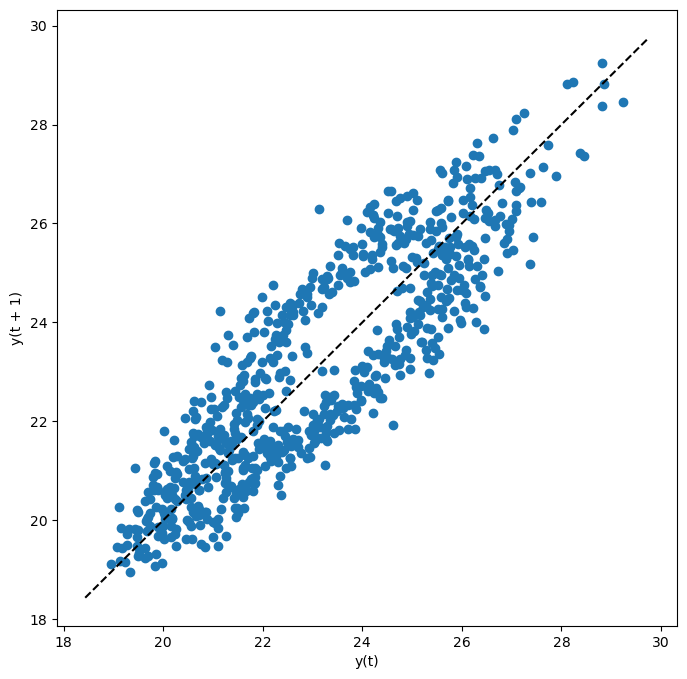

```python
fig, ax = plt.subplots(figsize=(8, 8))

pd.plotting.lag_plot( ready_series, lag=1, ax=ax )

ax.plot( ax.get_xlim(), ax.get_ylim(), 'k--')

plt.show()
```

We could also consider 2 lags. In our current example this would correspond to 2 months prior. The `lag` argument in the `.plotting.lag_plot()` function is specified to `lag=2` below. This plot examines the relationship between measurements that are two months apart. For example, we are comparing measurements in June to measurements in April.

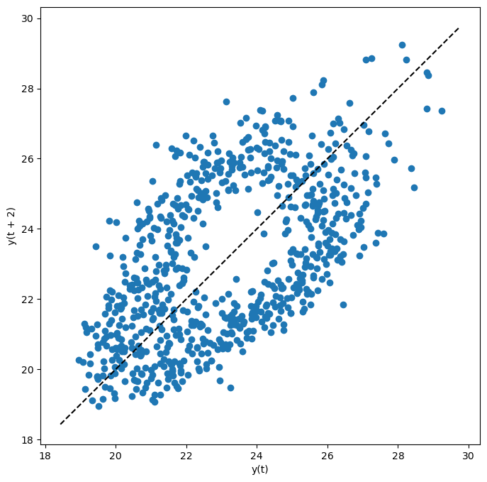

```python
fig, ax = plt.subplots(figsize=(8, 8))

pd.plotting.lag_plot( ready_series, lag=2, ax=ax )

ax.plot( ax.get_xlim(), ax.get_ylim(), 'k--')

plt.show()
```

We can keep going, we can consider 3 lags.

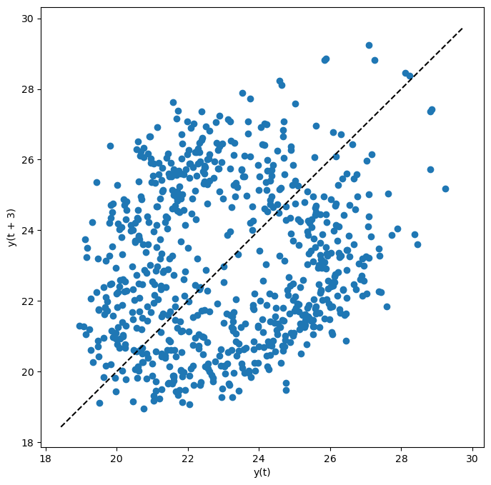

```python
fig, ax = plt.subplots(figsize=(8, 8))

pd.plotting.lag_plot( ready_series, lag=3, ax=ax )

ax.plot( ax.get_xlim(), ax.get_ylim(), 'k--')

plt.show()
```

What if we considered a lag of 12? In our application, that would correspond to the previous year! We would thus be comparing the temperature value at the same month, one year prior! Therefore, we would be looking at the correlation between observations of the same season!

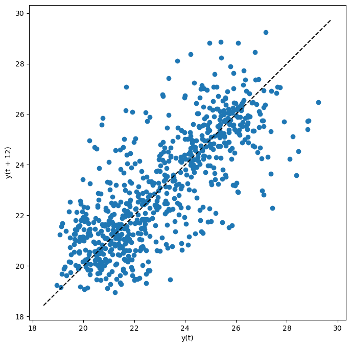

```python
fig, ax = plt.subplots(figsize=(8, 8))

pd.plotting.lag_plot( ready_series, lag=12, ax=ax )

ax.plot( ax.get_xlim(), ax.get_ylim(), 'k--')

plt.show()
```

Let's create a series of lag plots and visualize them within a plot grid. The faceted lag plot lets us exmine the autocorrelation structure across numerous lags!

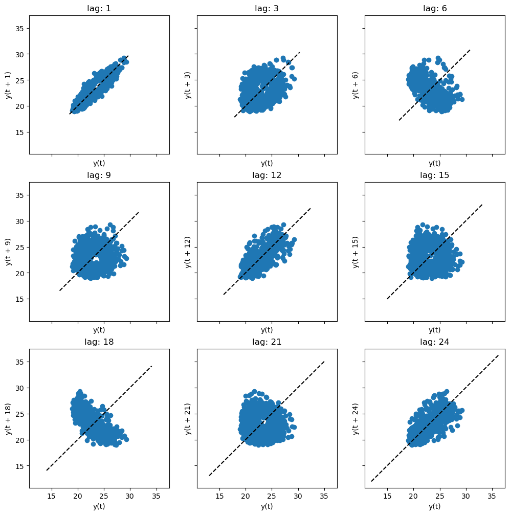

```python
lags_use = [1, 3, 6, 9, 12, 15, 18, 21, 24]

fig, ax = plt.subplots(3, 3, figsize=(12, 12), sharex=True, sharey=True)

ax = ax.ravel()

for k in range(len(lags_use)):
    pd.plotting.lag_plot( ready_series, lag=lags_use[k], ax=ax[k] )
    ax[k].plot( ax[k].get_xlim(), ax[k].get_ylim(), 'k--')
    ax[k].set_title('lag: ' + str(lags_use[k]) )

plt.show()
```

Alternatively, we can examine the autocorrelation behavior with autocorrelation plots. The autocorrelation plot contains the same information as examining numerous different lag plots. However, the autocorrelation plot takes some getting used to. We can create the autocorrelation plot two different ways. The first approach shown below uses `statsmodels` plotting functions.

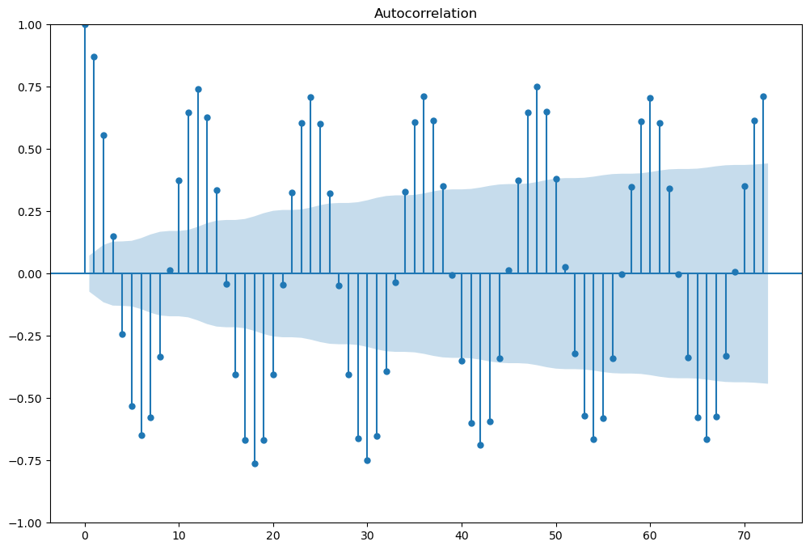

```python
fig, ax = plt.subplots( figsize = (12, 8) )

sm.graphics.tsa.plot_acf( ready_series.values.squeeze(), lags=72, ax = ax)

plt.show()
```

Alternatively, we can use the Pandas `autocorrelation_plot()` method.

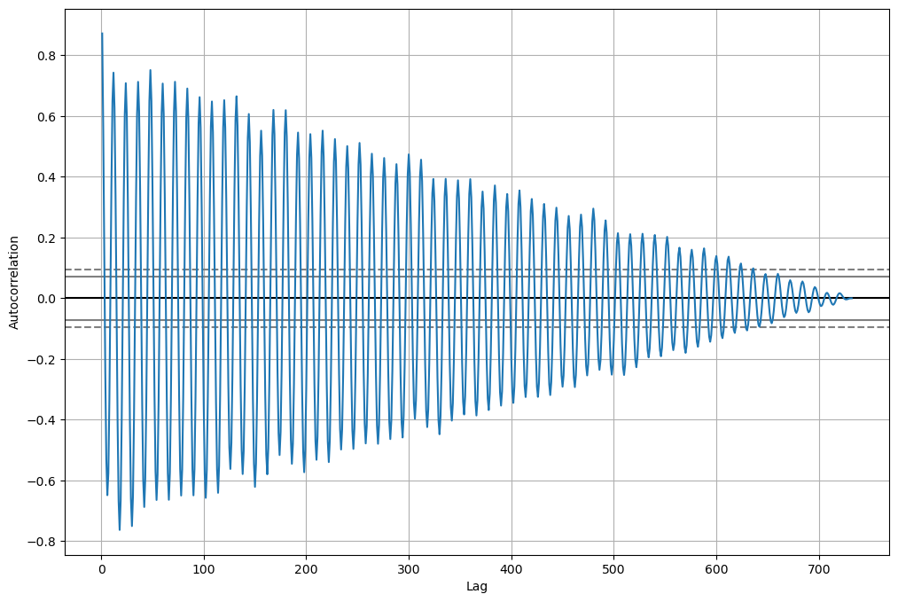

```python
fig, ax = plt.subplots(figsize=(12, 8))

pd.plotting.autocorrelation_plot( ready_series, ax = ax )

plt.show()
```

I typically use the `statsmodels` option since I feel it is easy to control than the Pandas method when visualizing the autocorrelation.

## Time series decomposition

We have explored the time series data. We have learned that values are **correlated** with values from the previous year. That suggests there could be a regularly occuring pattern that repeats each year. Time series methods refer to such patterns as **seasonal patterns**. A season corresponds to the **sampling frequency** of the data. Thus, one season in our current application is 1 month. Let's apply techniques to explore the **seasonality** to identify the commonly repeating pattern present in the data. We will do so by **decomposing** the data!

Let's decompose our time series with the classic additive decomposition approach. The `statsmodels` method documentation is below.

https://www.statsmodels.org/stable/generated/statsmodels.tsa.seasonal.seasonal_decompose.html

The function is `sm.tsa.seasonal_decompose()`. The first argument is a Pandas Series with the DateTimeIndex properly identified.

```python
my_decomposition = sm.tsa.seasonal_decompose(ready_series, model='additive')
```

We can plot the decomposition with the built in plotting method associated with the decomposition object.

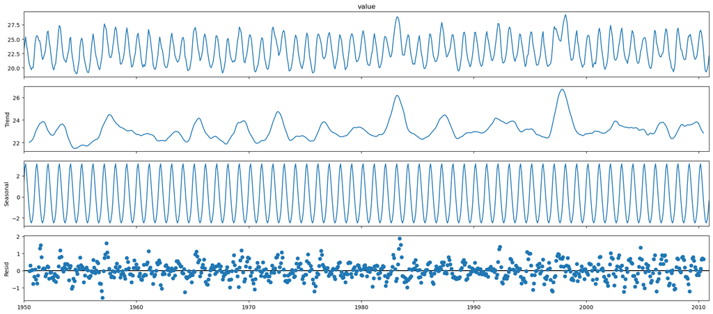

```python
plt.rcParams['figure.figsize'] = 18,8
plt.show()

fig = my_decomposition.plot()
```

The decomposition allows us to easily calculate the **seasonally adjusted** trend by subtracting the seasonal component from the observed values. Let's create a new DataFrame to help with the following visualizations so we can use Seaborn to make the figures.

```python
df_decomp = pd.DataFrame({'observed': my_decomposition.observed,
                          'seasonal_adjusted': my_decomposition.observed - my_decomposition.seasonal},
                        index=ready_series.index)
```

We can now use the wide-format plotting in Seaborn to easily compare the observed and seasonally adjusted trends.

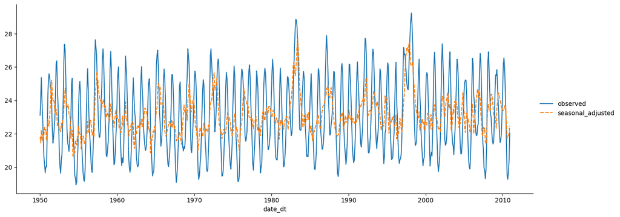

```python
sns.relplot( data = df_decomp, kind='line', aspect=2.5 )

plt.show()
```

Let's take a look at the variation across years within each month. The `sm.graphics.tsa.month_plot()` function shows the average value per month in red. The black line is the observed value within the month across the years. The month plot shows how the Seasonal pattern in the data. There is a difference in the average monthly values in the second half of the calendar year compared to the first half! However, the plot below includes the trend and thus makes it difficult to visualize if the seasonal pattern changes over time!

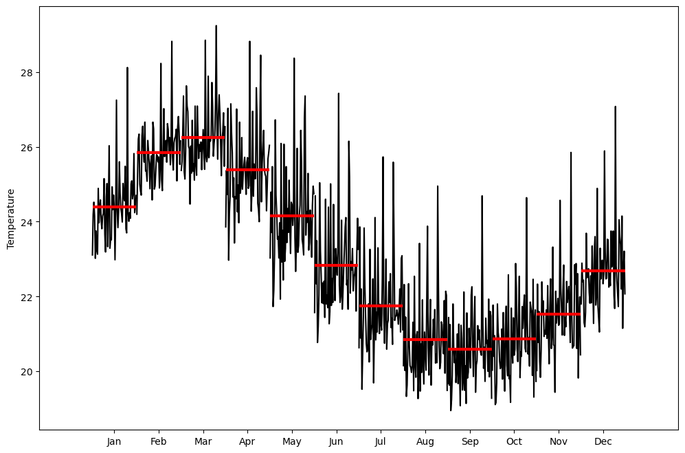

```python
fig, ax = plt.subplots(figsize=(12, 8))

sm.graphics.tsa.month_plot( ready_series, ylabel='Temperature', ax=ax )

plt.show()
```

The classical additive decomposition method returns NaN values for the `.trend` attribute at the beginning and end of the series. This is because of how the Moving Average procedure works. The NaN values are shown at the head and tail of `.trend` below.

```python
my_decomposition.trend
```

```
date_dt
1950-01-01   NaN
1950-02-01   NaN
1950-03-01   NaN
1950-04-01   NaN
1950-05-01   NaN
              ..
2010-08-01   NaN
2010-09-01   NaN
2010-10-01   NaN
2010-11-01   NaN
2010-12-01   NaN
Freq: MS, Name: trend, Length: 732, dtype: float64
```

The presentation slides for this week discuss why this happens in detail. A quick discussion as to why is that the Moving Average cannot calculate the smooth trend at the beginning and end. The Moving Average calculates a smooth trend "in the middle". The first non NaN value occurs in July in the first year.

```python
my_decomposition.trend[:12]
```

```
date_dt
1950-01-01          NaN
1950-02-01          NaN
1950-03-01          NaN
1950-04-01          NaN
1950-05-01          NaN
1950-06-01          NaN
1950-07-01    21.998333
1950-08-01    22.088333
1950-09-01    22.142917
1950-10-01    22.215417
1950-11-01    22.351667
1950-12-01    22.555000
Freq: MS, Name: trend, dtype: float64
```

The last non NaN value occurs in June of the last year.

```python
my_decomposition.trend[-12:]
```

```
date_dt
2010-01-01    23.658333
2010-02-01    23.470000
2010-03-01    23.272500
2010-04-01    23.101250
2010-05-01    22.957083
2010-06-01    22.845000
2010-07-01          NaN
2010-08-01          NaN
2010-09-01          NaN
2010-10-01          NaN
2010-11-01          NaN
2010-12-01          NaN
Freq: MS, Name: trend, dtype: float64
```

Why does this matter? We have already explored the **seasonally adjusted** behavior, but there are other components we can examine. The **detrended** behavior subtracts the "macro" trend from the observed values. This allows isolating the changes in each month over time. The classical additive method cannot calculate the **detrended** values for all months because of the NaN.

However, we can still examine the seasonal behavior by using the `.seasonal` attribute. This is the change within a month after removing the "macro" trend and the noisy residual (error). The month plot for the seasonal component is shown below, but it is rather boring. That is because the classical additive method **assumes** the seasonal component does **not** change over the years. The value per month is the same for all years! For our current example, that means March is always greater than February!

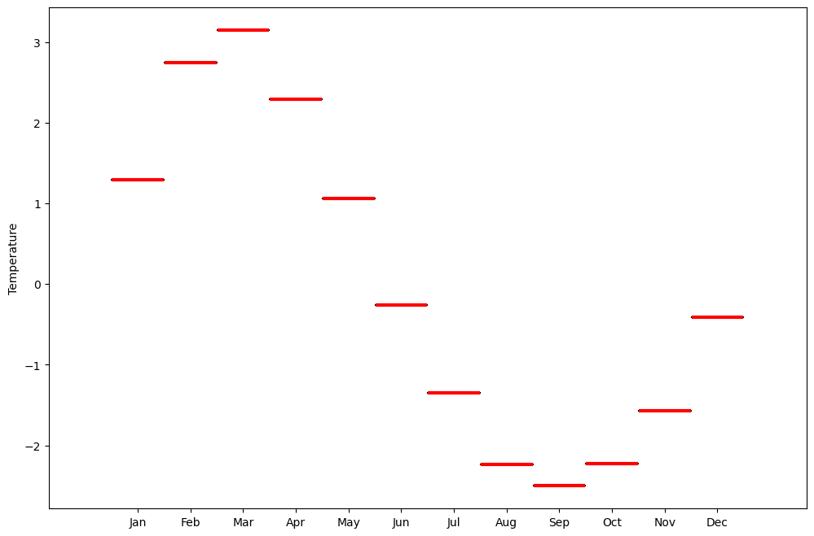

```python
fig, ax = plt.subplots(figsize=(12, 8))

sm.graphics.tsa.month_plot( my_decomposition.seasonal, ylabel='Temperature', ax=ax )

plt.show()
```

If we would like to see if the seasonal behavior changes over time, we must use a more complicated decomposition method. `statsmodels` includes the Seasonal and Trend decomposition using LOESS (STL) method. So let's try that approach below.

```python
from statsmodels.tsa.seasonal import STL
```

The STL decomposition result is assigned to the `ready_stl` object below.

```python
ready_stl = STL( ready_series )
```

The STL method is fit by calling the `.fit()` method. It's a little difficult to see but if you look closely the Seasonal pattern is **NOT** constant overtime! The amplitude is "undulating " or varying up and down as the years change.

```python
ready_stl_fit = ready_stl.fit()
```

The decomposition figure is shown below.

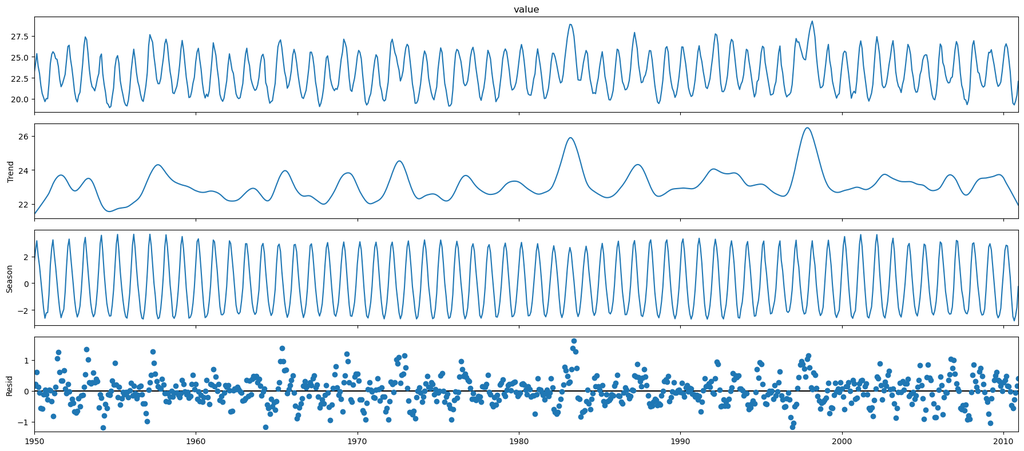

```python
fig = ready_stl_fit.plot()
```

The STL fitted object does include the `.trend` attribute!

```python
ready_stl_fit.trend
```

```
date_dt
1950-01-01    21.387036
1950-02-01    21.486001
1950-03-01    21.588166
1950-04-01    21.693680
1950-05-01    21.802330
                ...
2010-08-01    22.526164
2010-09-01    22.377637
2010-10-01    22.227452
2010-11-01    22.076353
2010-12-01    21.925026
Freq: MS, Name: trend, Length: 732, dtype: float64
```

We can therefore explore the **detrended** data and the **seasonally adjusted** data!

```python
df_stl = pd.DataFrame({'observed': ready_stl_fit.observed,
                       'seasonal_adjusted': ready_stl_fit.observed - ready_stl_fit.seasonal,
                       'detrend': ready_stl_fit.observed - ready_stl_fit.trend},
                      index=ready_series.index)
```

Plotting the observed data, seasonally adjusted data, and the detrended data on the same chart looks wrong! That is because the **detrended** data has the "macro trend" removed! The magnitude and scale can be different compared to the raw data. A **detrended** value of 0 does **not** mean the raw data are zero. A detrended value of zero means that month does **not** deviate from the "macro trend".

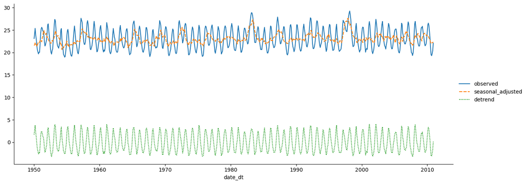

```python
sns.relplot( data = df_stl, kind='line', aspect=2.5 )

plt.show()
```

Thus, even when we detrend the data, we should instead focus on the observed and seasonally adjusted comparison:

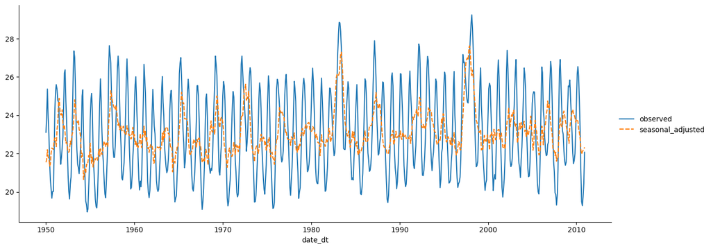

```python
sns.relplot( data = df_stl.loc[:, ['observed', 'seasonal_adjusted']], kind='line', aspect=2.5 )

plt.show()
```

The detrended data allows us to study if the seasonal effects change overtime. The detrended data can be easily visualized as the variation around the monthly average change!

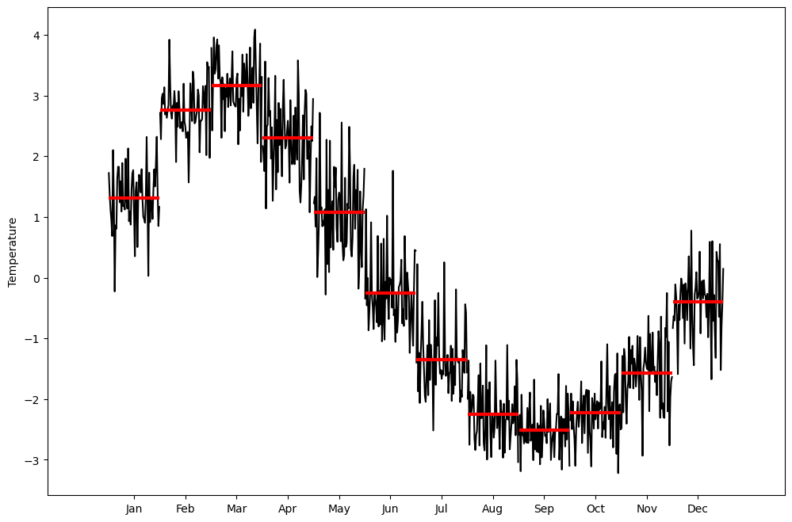

```python
fig, ax = plt.subplots(figsize=(12, 8))

sm.graphics.tsa.month_plot( df_stl.detrend, ylabel='Temperature', ax=ax )

plt.show()
```

The detrended data can be further smoothed by removing the **residual**!

```python
df_stl['detrend_smooth'] = ready_stl_fit.observed - (ready_stl_fit.trend + ready_stl_fit.resid)
```

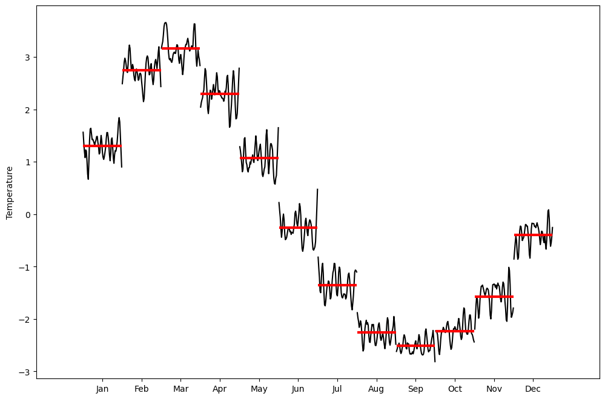

```python
fig, ax = plt.subplots(figsize=(12, 8))

sm.graphics.tsa.month_plot( df_stl.detrend_smooth, ylabel='Temperature', ax=ax )

plt.show()
```

But, the above figure is equivalent to visualizing the `.seasonal` component with a month plot.

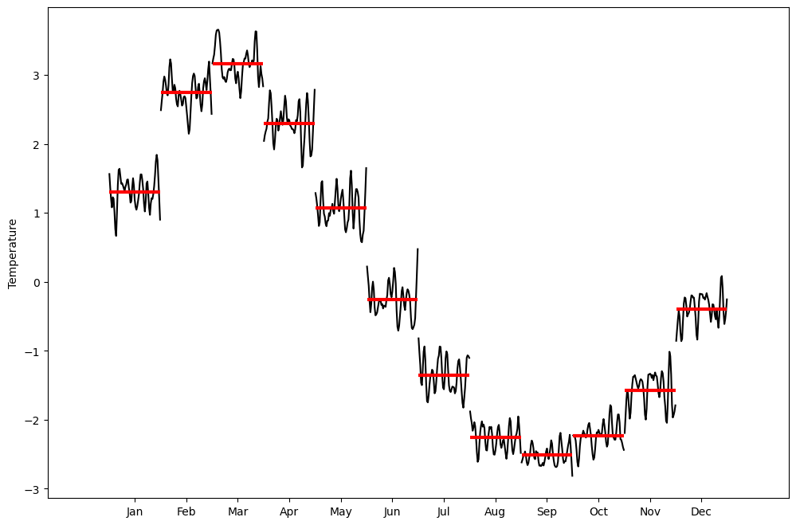

```python
fig, ax = plt.subplots(figsize=(12, 8))

sm.graphics.tsa.month_plot( ready_stl_fit.seasonal, ylabel='Temperature', ax=ax )

plt.show()
```

## Conclusion

This report introduced organizing data for time series analysis, exploring the time series, and visually finding seasonal patterns with decompositions.